# Lab 2: Spatial Analysis and Visualization

### Your Analysis

**Your Task:**

1. **Find and load additional data**
   - Document your data source
   - Check and standardize the CRS
   - Provide basic summary statistics

**Questions to answer:** - What dataset did you choose and why? I chose three datasets from OpenDataPhilly: Philadelphia crime incidents (2020–2024 aggregate), traffic collision data (2020–2024), and school parcels. Crime and collision data were chosen because both directly affect student safety around schools. Violent crime threatens personal safety while traffic collisions are a major concern for students walking or biking to school.

- What is the data source and date? All datasets are from OpenDataPhilly, maintained by the City of Philadelphia. Crime and collision data span 2020–2024 and school parcels reflect current school locations.
- How many features does it contain? After filtering for relevant crime categories, the crime dataset contains 234,858 incidents across five years. The collision dataset contains 36,303 records over the same period.
- What CRS is it in? Did you need to transform it? All datasets are in EPSG 3857 (WGS 84 / Pseudo-Mercator), the same CRS as “pa_counties”. No additional transformation was needed since they already matched.
2. **Pose a research question**

Are school safety zones in Philadelphia’s high-violation tracts disproportionately exposed to crime incidents and traffic hazards?

**Examples:** - “Do vulnerable tracts have adequate public transit access to hospitals?” - “Are EMS stations appropriately located near vulnerable populations?” - “Do areas with low vehicle access have worse hospital access?”

3. **Conduct spatial analysis**

Use at least TWO spatial operations to answer your research question.

**Required operations (choose 2+):** - Buffers - Spatial joins - Spatial filtering with predicates - Distance calculations - Intersections or unions - Point-in-polygon aggregation

**Your Task:**

```r
## buffer school safety zone and calculate number of crime and collision for each school
# 1000ft = 304.8 meters in EPSG 3857
safety_zone <- schools %>%
  st_buffer(dist = 304.8)

# Spatial join
crime_in_buffer <- safety_zone %>%
  st_join(crime) %>%
  st_drop_geometry() %>%
  group_by(objectid.x) %>%
  summarise(crime_count = n()) %>%
  rename(objectid = objectid.x)

collision_in_buffer <- safety_zone %>%
  st_join(collision) %>%
  st_drop_geometry() %>%
  group_by(objectid.x) %>%
  summarise(collision_count = n()) %>%
  rename(objectid = objectid.x)

# Join counts
safety_zone <- schools %>%
  st_buffer(dist = 304.8) %>%
  left_join(crime_in_buffer, by = "objectid") %>%
  left_join(collision_in_buffer, by = "objectid") %>%
  mutate(
    crime_count = replace_na(crime_count, 0),
    collision_count = replace_na(collision_count, 0),
    danger_score = crime_count + collision_count
  )

##identify the top 5 dangerous school parcels by crime/collision/crime + collision (= danger)/
##top 20% crime and top 20% collision

# Flag high-violation schools (top 20% in BOTH crime and collision)
crime_cut <- quantile(safety_zone$crime_count, 0.80, na.rm = TRUE)
collision_cut <- quantile(safety_zone$collision_count, 0.80, na.rm = TRUE)

safety_zone <- safety_zone %>%
  mutate(high_violation = crime_count >= crime_cut & collision_count >= collision_cut)
sum(safety_zone$high_violation)
```

```
[1] 52
```

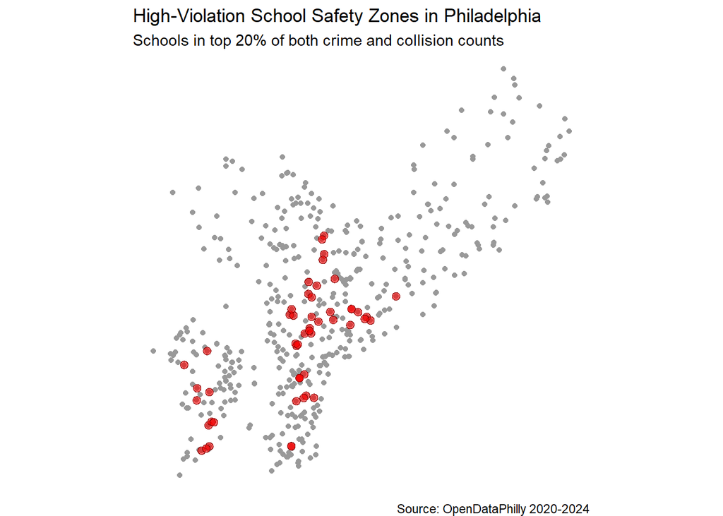

```r
ggplot() +
  geom_sf(data = schools, fill = "gray90", color = "gray60", linewidth = 0.3) +
  geom_sf(data = safety_zone %>% filter(high_violation),
          fill = "red", alpha = 0.6, color = "darkred", linewidth = 0.3) +
  labs(
    title = "High-Violation School Safety Zones in Philadelphia",
    subtitle = "Schools in top 20% of both crime and collision counts",
    caption = "Source: OpenDataPhilly 2020-2024"
  ) +
  theme_void()
```

```r
# top 5 dangerous school parcels
top5_crime <- safety_zone %>%
  st_drop_geometry() %>%
  arrange(desc(crime_count)) %>%
  head(5) %>%
  select(objectid, school_nam, crime_count, collision_count, danger_score) %>%
  kable(caption = "Top 5 Schools by Crime Count",
        col.names = c("ID", "School Name", "Crime Count", "Collision Count", "Danger Score")) %>%
  kable_styling(bootstrap_options = c("striped", "hover"), full_width = FALSE)

top5_collision <- safety_zone %>%
  st_drop_geometry() %>%
  arrange(desc(collision_count)) %>%
  head(5) %>%
  select(objectid, school_nam, crime_count, collision_count, danger_score) %>%
  kable(caption = "Top 5 Schools by Collision Count",
        col.names = c("ID", "School Name", "Crime Count", "Collision Count", "Danger Score")) %>%
  kable_styling(bootstrap_options = c("striped", "hover"), full_width = FALSE)

top5_danger <- safety_zone %>%
  st_drop_geometry() %>%
  arrange(desc(danger_score)) %>%
  head(5) %>%
  select(objectid, school_nam, crime_count, collision_count, danger_score) %>%
  kable(caption = "Top 5 Schools by Combined Danger Score",
        col.names = c("ID", "School Name", "Crime Count", "Collision Count", "Danger Score")) %>%
  kable_styling(bootstrap_options = c("striped", "hover"), full_width = FALSE)

top5_crime
```

Top 5 Schools by Crime Count

| ID | School Name | Crime Count | Collision Count | Danger Score |
| --- | --- | --- | --- | --- |
| 86 | CONWELL, RUSSELL MIDDLE SCHOOL | 2053 | 46 | 2099 |
| 315 | WILLARD, FRANCES E. SCHOOL | 1400 | 44 | 1444 |
| 222 | FREIRE CHARTER SCHOOL | 1159 | 60 | 1219 |
| 464 | K012 KIDS SCHOOL | 1126 | 68 | 1194 |
| 70 | VISITATION SCHOOL | 912 | 74 | 986 |

```r
top5_collision
```

Top 5 Schools by Collision Count

| ID | School Name | Crime Count | Collision Count | Danger Score |
| --- | --- | --- | --- | --- |
| 119 | DUCKREY, TANNER SCHOOL | 566 | 150 | 716 |
| 137 | ROMAN CATHOLIC HIGH SCHOOL | 330 | 141 | 471 |
| 331 | KENDERTON ELEMENTARY | 380 | 133 | 513 |
| 313 | YOUTHBUILD PHILADELPHIA CHARTER | 659 | 123 | 782 |
| 452 | TECH FREIRE CHARTER SCHOOL | 618 | 123 | 741 |

```r
top5_danger
```

Top 5 Schools by Combined Danger Score

| ID | School Name | Crime Count | Collision Count | Danger Score |
| --- | --- | --- | --- | --- |
| 86 | CONWELL, RUSSELL MIDDLE SCHOOL | 2053 | 46 | 2099 |
| 315 | WILLARD, FRANCES E. SCHOOL | 1400 | 44 | 1444 |
| 222 | FREIRE CHARTER SCHOOL | 1159 | 60 | 1219 |
| 464 | K012 KIDS SCHOOL | 1126 | 68 | 1194 |
| 70 | VISITATION SCHOOL | 912 | 74 | 986 |

```r
##calculate the average distance from danger point in a school buffer to the school
schools <- rename(schools, OBJECTID = objectid)

# Crime distances
crime_dist_matrix <- st_distance(crime, schools)

crime_dist <- crime %>%
  mutate(dist_to_school = apply(crime_dist_matrix, 1, min)) %>%
  st_join(safety_zone %>% select(objectid)) %>%
  st_drop_geometry() %>%
  group_by(objectid.y) %>%
  summarise(avg_crime_dist = mean(dist_to_school, na.rm = TRUE)) %>%
  rename(objectid = objectid.y)

safety_zone <- safety_zone %>%
  left_join(crime_dist, by = "objectid")

# Collision distances
collision_dist_matrix <- st_distance(collision, schools)

collision_dist <- collision %>%
  mutate(dist_to_school = apply(collision_dist_matrix, 1, min)) %>%
  st_join(safety_zone %>% select(objectid)) %>%
  st_drop_geometry() %>%
  group_by(objectid.y) %>%
  summarise(avg_collision_dist = mean(dist_to_school, na.rm = TRUE)) %>%
  rename(objectid = objectid.y)

safety_zone <- safety_zone %>%
  left_join(collision_dist, by = "objectid")

# Top 5 by average crime distance
top5_crime_dist <- safety_zone %>%
  st_drop_geometry() %>%
  arrange(avg_crime_dist) %>%
  head(5) %>%
  select(objectid, school_nam, avg_crime_dist) %>%
  kable(caption = "Top 5 Schools with Least Average Crime Distance (meters)",
        col.names = c("ID", "School Name", "Avg Crime Distance (m)")) %>%
  kable_styling(bootstrap_options = c("striped", "hover"), full_width = FALSE)

# Top 5 by average collision distance
top5_collision_dist <- safety_zone %>%
  st_drop_geometry() %>%
  arrange(avg_collision_dist) %>%
  head(5) %>%
  select(objectid, school_nam, avg_collision_dist) %>%
  kable(caption = "Top 5 Schools by Average Collision Distance (meters)",
        col.names = c("ID", "School Name", "Avg Collision Distance (m)")) %>%
  kable_styling(bootstrap_options = c("striped", "hover"), full_width = FALSE)

top5_crime_dist
```

Top 5 Schools with Least Average Crime Distance (meters)

| ID | School Name | Avg Crime Distance (m) |
| --- | --- | --- |
| 73 | NAZARETH ACADEMY HIGH SCHOOL | 39.56615 |
| 384 | MATH, SCIENCE AND TECHNOLOGY | 55.24363 |
| 473 | NA | 100.19317 |
| 304 | ROXBOROUGH HIGH SCHOOL | 100.85450 |
| 130 | FELTONVILLE ARTS & SCIENCES | 114.11754 |

```r
top5_collision_dist
```

Top 5 Schools by Average Collision Distance (meters)

| ID | School Name | Avg Collision Distance (m) |
| --- | --- | --- |
| 186 | MIFFLIN, THOMAS SCHOOL | 95.84298 |
| 153 | PENNSYLVANIA SCHOOL FOR THE DEAF | 104.24374 |
| 173 | CARNELL, LAURA H. SCHOOL | 110.58027 |
| 467 | SAINTS TABERNACLE DAY SCHOOL | 114.22460 |
| 254 | MASTERY CHARTER @ PICKETT | 116.87737 |

```r
# Flag schools with least 20% crime distance and least 20% collision distance
crime_dist_cut <- quantile(safety_zone$avg_crime_dist, 0.20, na.rm = TRUE)
collision_dist_cut <- quantile(safety_zone$avg_collision_dist, 0.20, na.rm = TRUE)

safety_zone <- safety_zone %>%
  mutate(high_violation_dist = avg_crime_dist <= crime_dist_cut & avg_collision_dist <= collision_dist_cut)
cat("Number of high-violation distance schools:", sum(safety_zone$high_violation_dist, na.rm = TRUE), "\n")
```

```
Number of high-violation distance schools: 46
```

```r
##aggregate by census tract and county
# Step 5: Aggregate by census tract and county
# First transform census_tracts to match CRS
pa_tract <- st_transform(pa_tract, st_crs(safety_zone))

# Spatial join safety_zone to census tracts
safety_zone_tracts <- safety_zone %>%
  st_join(pa_tract %>% select(GEOID, NAME)) %>%
  st_drop_geometry() %>%
  group_by(GEOID, NAME) %>%
  summarise(
    n_schools = n(),
    n_high_violation = sum(high_violation, na.rm = TRUE),
    n_high_violation_dist = sum(high_violation_dist, na.rm = TRUE),
    avg_crime_count = mean(crime_count, na.rm = TRUE),
    avg_collision_count = mean(collision_count, na.rm = TRUE),
    avg_crime_dist = mean(avg_crime_dist, na.rm = TRUE),
    avg_collision_dist = mean(avg_collision_dist, na.rm = TRUE)
  ) %>%
  mutate(
    high_violation_rate = n_high_violation / n_schools * 100,
    high_violation_dist_rate = n_high_violation_dist / n_schools * 100,
    tract_num = str_extract(NAME, "(?<=Census Tract )\\d+\\.?\\d*")
  ) %>%
  arrange(desc(n_high_violation))
```

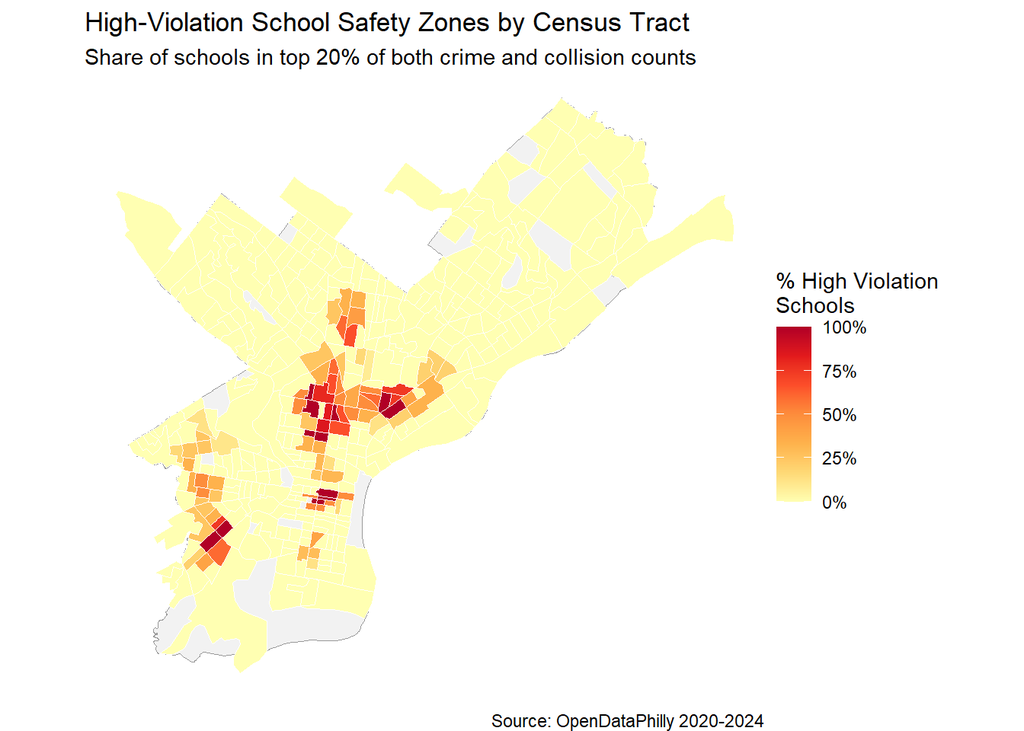

```r
##visualization
# Visualization 1: Tract-level choropleth map
tract_map <- pa_tract %>%
  left_join(safety_zone_tracts %>% st_drop_geometry(), by = "GEOID") %>%
  filter(!is.na(high_violation_rate))

ggplot() +
  geom_sf(data = pa_counties %>% filter(COUNTY_NAM == "PHILADELPHIA"),
          fill = "gray95", color = "gray60", linewidth = 0.3) +
  geom_sf(data = tract_map,
          aes(fill = high_violation_rate),
          color = "white", linewidth = 0.2) +
  scale_fill_distiller(
    palette = "YlOrRd",
    direction = 1,
    na.value = "gray90",
    name = "% High Violation\nSchools",
    labels = scales::label_percent(scale = 1)
  ) +
  labs(
    title = "High-Violation School Safety Zones by Census Tract",
    subtitle = "Share of schools in top 20% of both crime and collision counts",
    caption = "Source: OpenDataPhilly 2020-2024"
  ) +
  theme_void()
```

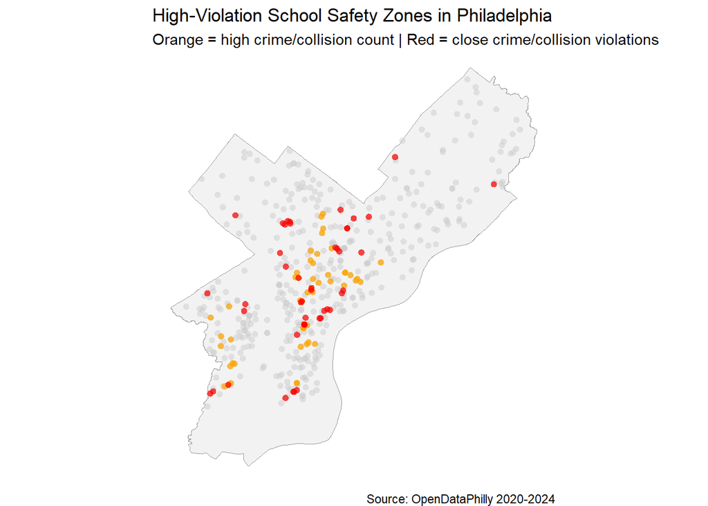

```r
# Visualization 2: Compare high_violation vs high_violation_dist
ggplot() +
  geom_sf(data = pa_counties %>% filter(COUNTY_NAM == "PHILADELPHIA"),
          fill = "gray95", color = "gray60", linewidth = 0.3) +
  geom_sf(data = safety_zone,
          fill = "gray80", color = NA, alpha = 0.5) +
  geom_sf(data = safety_zone %>% filter(high_violation),
          fill = "orange", color = NA, alpha = 0.7) +
  geom_sf(data = safety_zone %>% filter(high_violation_dist),
          fill = "red", color = NA, alpha = 0.7) +
  labs(
    title = "High-Violation School Safety Zones in Philadelphia",
    subtitle = "Orange = high crime/collision count | Red = close crime/collision violations",
    caption = "Source: OpenDataPhilly 2020-2024"
  ) +
  theme_void()
```

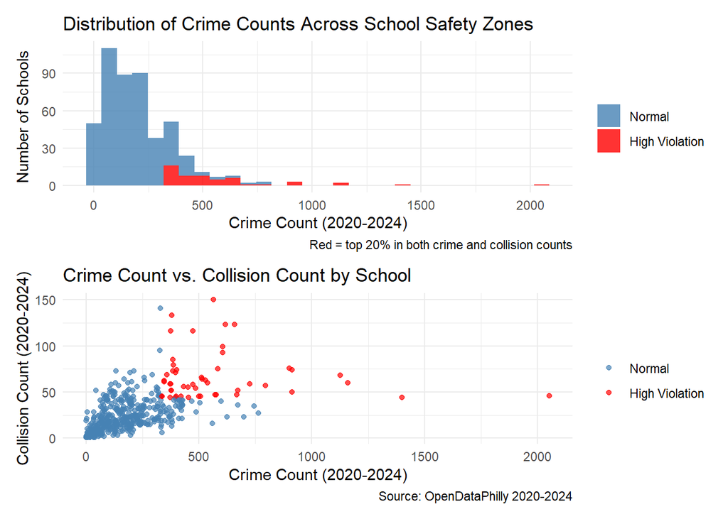

```r
# Visualization 3: Crime and Collision Distribution Across Philadelphia School Safety Zones
p3 <- ggplot(safety_zone, aes(x = crime_count, fill = high_violation)) +
  geom_histogram(bins = 30, alpha = 0.8) +
  scale_fill_manual(
    values = c("FALSE" = "steelblue", "TRUE" = "red"),
    labels = c("FALSE" = "Normal", "TRUE" = "High Violation"),
    name = ""
  ) +
  labs(
    title = "Distribution of Crime Counts Across School Safety Zones",
    x = "Crime Count (2020-2024)",
    y = "Number of Schools",
    caption = "Red = top 20% in both crime and collision counts"
  ) +
  theme_minimal()

# p2: Scatter plot of crime_count vs collision_count colored by high_violation
p4 <- ggplot(safety_zone, aes(x = crime_count, y = collision_count, color = high_violation)) +
  geom_point(alpha = 0.7) +
  scale_color_manual(
    values = c("FALSE" = "steelblue", "TRUE" = "red"),
    labels = c("FALSE" = "Normal", "TRUE" = "High Violation"),
    name = ""
  ) +
  labs(
    title = "Crime Count vs. Collision Count by School",
    x = "Crime Count (2020-2024)",
    y = "Collision Count (2020-2024)",
    caption = "Source: OpenDataPhilly 2020-2024"
  ) +
  theme_minimal()

p3 / p4
```

**Analysis requirements:** - Clear code comments explaining each step - Appropriate CRS transformations - Summary statistics or counts - At least one map showing your findings - Brief interpretation of results (3-5 sentences)

**Your interpretation:** This analysis examined 490 school safety zones across Philadelphia using crime incident and traffic collision data from 2020 to 2024. Of the 490 schools, 52 (10.6%) were classified as high-violation by count — falling in the top 20% of both crime and collision counts — while 46 schools (9.4%) were flagged as high-violation by distance, meaning violations tend to cluster very close to the school itself. The histogram shows that most schools have fewer than 500 crime incidents over the five-year period, with high-violation schools appearing at the higher end of the distribution, confirming that the top 20% threshold effectively separates genuinely dangerous zones from the rest. The scatter plot further reveals a positive relationship between crime count and collision count — schools with more crime also tend to have more collisions — and high-violation schools cluster distinctly in the upper right, indicating that danger tends to be compounded rather than isolated to a single incident type. At the census tract level, dangerous school zones are mostly concentrated in tracts along North Broad Street, Kensington, and West Philadelphia, underscoring the need for targeted Safe Routes to School investments in these specific corridors where students face both high volumes of crime and violations occurring in close proximity to school grounds.

## Finally - A few comments about your incorporation of feedback!

I try to avoid unnecessary code like print() and head(). Besides, I used “#| echo: false, #| message: false, and #| results: hide” to hide setup code.

## Submission Requirements

**What to submit:**

1. **Rendered HTML document posted to your course portfolio** with all code, outputs, maps, and text
   - Use `embed-resources: true` in YAML so it’s a single file
   - All code should run without errors
   - All maps and charts should display correctly
2. Submit the correct and working links of your assignment on Canvas